# Simulation

Jingyi

11/5/2019

# Example

I’ll write code for today’s content in a new R Markdown document called simulation.Rmd in the iteration directory / repo. The code chunk below loads the usual packages and sets a seed for reproducibility.

```r
library(tidyverse)
set.seed(1)
```

## Simulation: SLR for one n

In writing functions we wrote a short function to simulate data from a simple linear regression, fit the regression model, and return estimates of regression coefficients. Specifically, we generate data from

y_i = β_0 + β_1 x_i + ϵ_i

for subjects 1≤i≤n with ϵ_i∼N[0,1] and return estimates

β^0 , β^1 . That function is below.

```r
sim_regression = function(n, beta0 = 2, beta1 = 3) {

  sim_data = tibble(
    x = rnorm(n, mean = 1, sd = 1),
    y = beta0 + beta1 * x + rnorm(n, 0, 1)
  )

  ls_fit = lm(y ~ x, data = sim_data)

  tibble(
    beta0_hat = coef(ls_fit)[1],
    beta1_hat = coef(ls_fit)[2]
  )
}
```

(Because our simulation design generates errors from a Normal distribution we also know that the estimates follow a Normal distribution, although that’s not guaranteed by least squares estimation.)

In the real world, drawing samples is time consuming and costly, so “repeated sampling” remains conceptual. On a computer, though, drawing samples is pretty easy. That makes simulation an appealing way to examine the statistical properties of your estimators.

```r
output = vector("list", 100)

for (i in 1:100) {
  output[[i]] = sim_regression(30)
}

sim_results = bind_rows(output)
```

Taking a look at the for loop we used to create these results, you might notice that there’s no input list – the sequence is used to keep track of the output but doesn’t affect the computation performed inside the for loop. In cases like these, the purrr::rerun function is very handy.

```r
sim_results =
  rerun(100, sim_regression(30, 2, 3)) %>%
  bind_rows()
```

Structurally, rerun is a lot like map – the first argument defines the amount of iteration and the second argument is the function to use in each iteration step. As with map, we’ve replaced a for loop with a segment of code that makes our purpose much more transparent but both approaches give the same results.

Let’s make some quick plots and compute some summaries for our simulation results.

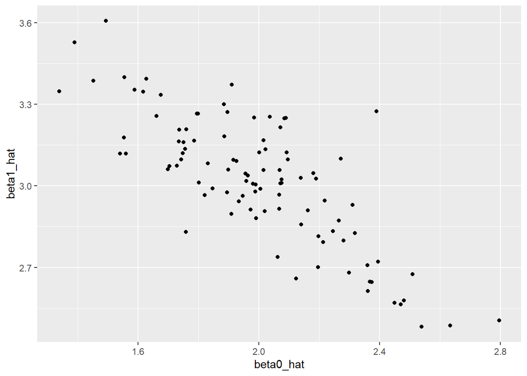

```r
sim_results %>%
  ggplot(aes(x = beta0_hat, y = beta1_hat)) +
  geom_point()
```

```r
sim_results %>%
  pivot_longer(
    beta0_hat:beta1_hat,
    names_to = "parameter",
    values_to = "estimate") %>%
  group_by(parameter) %>%
  summarize(emp_mean = mean(estimate),
            emp_var = var(estimate)) %>%
  knitr::kable(digits = 3)
```

| parameter | emp_mean | emp_var |
| --- | --- | --- |
| beta0_hat | 1.995 | 0.081 |
| beta1_hat | 3.021 | 0.056 |

This is great! We’ve seen how our estimates are distributed under our simulation scenario, and can compare empirical results to theoretical ones. In this way, we can build intution for fundamental statistical procedures under repeated sampling in a way that’s not possible with single data sets.

## Simulation: SLR for several n’s

Sample size makes a huge difference on the variance of estimates in SLR (and pretty much every statistical method). Let’s try to clarify that effect through simulating at a few sample sizes.

I’ll start this process with a for loop around the code I established above using rerun (I could start from scratch by nesting one for loop in another for loop, but let’s not).

```r
n_list = list("n_30" = 30,
              "n_60" = 60,
              "n_120" = 120,
              "n_240" = 240)

output = vector("list", length = 4)

for (i in 1:4) {
  output[[i]] = rerun(100, sim_regression(n_list[[i]])) %>%
    bind_rows
}
```

After this loop, output is a list of 4 data frames; each data frame contains the results of 100 simulations at different sample sizes.

Before we spend time looking at the results of the simulation, let’s recast this using list columns and map. I’ll set up a tibble with the sample sizes I want to investigate, and then use rerun to perform the complete simulation for each sample size. Remember that rerun produces a list, so I’m going to use bind_rows to produce a tibble of simulation results for each sample size. Finally, I’ll unnest the tibbles to produce a standard data frame with no list columns.

```r
sim_results =
  tibble(sample_size = c(30, 60, 120, 240)) %>%
  mutate(
    output_lists = map(.x = sample_size, ~rerun(1000, sim_regression(n = .x))),
    estimate_dfs = map(output_lists, bind_rows)) %>%
  select(-output_lists) %>%
  unnest(estimate_dfs)
```

Let’s take a look at what we’ve accomplished in our simulations! First I’ll take a look at the distribution of slope estimates across sample sizes.

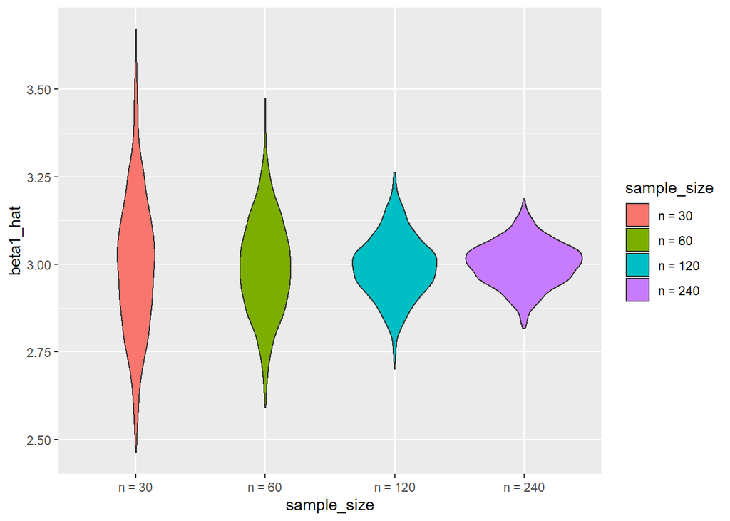

```r
sim_results %>%
  mutate(
    sample_size = str_c("n = ", sample_size),
    sample_size = fct_inorder(sample_size)) %>%
  ggplot(aes(x = sample_size, y = beta1_hat, fill = sample_size)) +
  geom_violin()
```

These estimates are centered around the truth (3) for each sample size, and the width of the distribution shrinks as sample size grows.

Next, I’ll look at the bivariate distribution of intercept and slope estimates across sample sizes.

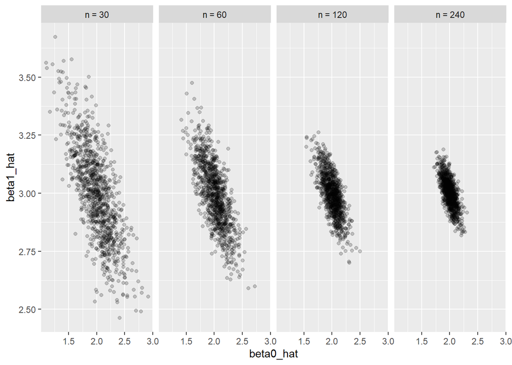

```r
sim_results %>%
  mutate(
    sample_size = str_c("n = ", sample_size),
    sample_size = fct_inorder(sample_size)) %>%
  ggplot(aes(x = beta0_hat, y = beta1_hat)) +
  geom_point(alpha = .2) +
  facet_grid(~sample_size)
```

The variability in the slope estimates was shown in the violin plot, but now we have a sense for the bivariate distribution of intercepts and slopes. Estimates of the intercept and slope are correlated with each other; this is expected from theoretical results describing the joint distribution of estimated regression coefficients.

Lastly I’ll look at the empirical mean and variance of these estimates.

```r
sim_results %>%
  pivot_longer(
    beta0_hat:beta1_hat,
    names_to = "parameter",
    values_to = "estimate") %>%
  group_by(parameter, sample_size) %>%
  summarize(emp_mean = mean(estimate),
            emp_var = var(estimate)) %>%
  knitr::kable(digits = 3)
```

| parameter | sample_size | emp_mean | emp_var |
| --- | --- | --- | --- |
| beta0_hat | 30 | 2.000 | 0.073 |
| beta0_hat | 60 | 2.011 | 0.037 |
| beta0_hat | 120 | 2.007 | 0.017 |
| beta0_hat | 240 | 2.000 | 0.008 |
| beta1_hat | 30 | 2.997 | 0.039 |
| beta1_hat | 60 | 2.993 | 0.019 |
| beta1_hat | 120 | 2.993 | 0.008 |
| beta1_hat | 240 | 3.002 | 0.004 |